# Impacto de desastres naturales — INDECI

Sesiones 3 y 4 · Análisis exploratorio y preparación de variables

Autor/a

Proyecto de análisis de datos

Fecha de publicación

19 de noviembre de 2026

## Objetivo y alcance

Analizar los resultados agregados por tipo de evento y región natural. **La fuente no contiene registros individuales**; las pruebas se muestran tal como aparecen en el Excel, sin recalcularlas.

## A0 · Carga y verificación

**Código**

```r
library(readr)
library(dplyr)
library(ggplot2)
library(knitr)
library(tidyr)
library(here)
library(scales)
leer <- function(nombre) read_csv(here("data", "processed", paste0(nombre, ".csv")), show_col_types = FALSE)
desc <- leer("1_Descriptivos")
normal <- leer("2_Shapiro_Wilk")
levene <- leer("3_Levene")
kw <- leer("4_Kruskal_Wallis")
dunn <- leer("5_Dunn_Bonferroni")
region <- leer("6_Region_Natural")
clasif <- leer("7_Clasificacion")
eta <- leer("8_Eta_cuadrado")
stopifnot(all(c("tipo_evento", "n", "media", "mediana") %in% names(desc)))
stopifnot(nrow(desc) > 0, nrow(kw) > 0)
tibble(Hoja = c("Descriptivos", "Shapiro-Wilk", "Levene", "Kruskal-Wallis", "Dunn", "Región", "Clasificación", "Eta cuadrado"), Filas = c(nrow(desc), nrow(normal), nrow(levene), nrow(kw), nrow(dunn), nrow(region), nrow(clasif), nrow(eta))) |> kable()
```

| Hoja | Filas |
| --- | --- |
| Descriptivos | 17 |
| Shapiro-Wilk | 17 |
| Levene | 1 |
| Kruskal-Wallis | 2 |
| Dunn | 136 |
| Región | 4 |
| Clasificación | 17 |
| Eta cuadrado | 1 |

## A1 · Análisis exploratorio orientado a hipótesis

### A1.1 Descriptivos de impacto

**Código**

```r
desc |> arrange(desc(total)) |> select(tipo_evento, grupo_impacto, n, media, mediana, P75, P95, total, pct_total, pct_ceros) |> kable(digits = 2)
```

| tipo_evento | grupo_impacto | n | media | mediana | P75 | P95 | total | pct_total | pct_ceros |
| --- | --- | --- | --- | --- | --- | --- | --- | --- | --- |
| INUNDACIÓN | Alto | 5786 | 94.0 | 0 | 7.0 | 175.0 | 543977 | 26.9 | 64.4 |
| LLUVIA INTENSA | Moderado-bajo | 25262 | 18.8 | 0 | 4.0 | 53.0 | 474939 | 23.5 | 70.2 |
| SISMO | Alto | 1368 | 338.5 | 0 | 28.5 | 576.2 | 463047 | 22.9 | 59.6 |
| INCENDIO URB. E INDUST. | Moderado-bajo | 22531 | 6.6 | 5 | 7.0 | 17.0 | 148340 | 7.3 | 25.3 |
| BAJAS TEMPERATURAS | Moderado-bajo | 13601 | 7.7 | 0 | 0.0 | 0.0 | 105100 | 5.2 | 96.0 |
| SEQUÍA | Moderado-alto | 2181 | 41.4 | 0 | 0.0 | 0.0 | 90347 | 4.5 | 97.7 |
| VIENTOS FUERTES | Bajo | 11810 | 6.0 | 0 | 2.0 | 27.0 | 70800 | 3.5 | 72.8 |
| HUAYCO | Moderado-bajo | 2276 | 20.4 | 0 | 1.0 | 80.0 | 46456 | 2.3 | 74.5 |
| DESLIZAMIENTO | Moderado-bajo | 3662 | 10.5 | 0 | 2.8 | 48.0 | 38612 | 1.9 | 73.4 |
| EROSIÓN | Moderado-bajo | 1297 | 11.9 | 1 | 6.0 | 54.0 | 15393 | 0.8 | 48.0 |
| INCENDIO FORESTAL | Bajo | 3276 | 1.8 | 0 | 0.0 | 5.0 | 5827 | 0.3 | 92.3 |
| MAREJADA | Moderado-alto | 122 | 47.1 | 0 | 0.0 | 16.9 | 5747 | 0.3 | 90.2 |
| TORMENTA ELÉCTRICA | Moderado-bajo | 483 | 9.2 | 0 | 2.0 | 15.0 | 4431 | 0.2 | 71.4 |
| ALUD | Moderado-alto | 123 | 34.4 | 0 | 12.0 | 155.6 | 4227 | 0.2 | 65.0 |
| DERRUMBE DE CERRO | Bajo | 940 | 2.1 | 0 | 0.0 | 8.0 | 1954 | 0.1 | 86.7 |
| ACTIVIDAD VOLCÁNICA | Moderado-bajo | 68 | 15.3 | 0 | 0.0 | 25.4 | 1038 | 0.1 | 94.1 |
| EXPLOSIÓN | Bajo | 83 | 3.7 | 0 | 0.0 | 18.6 | 305 | 0.0 | 81.9 |

**Código**

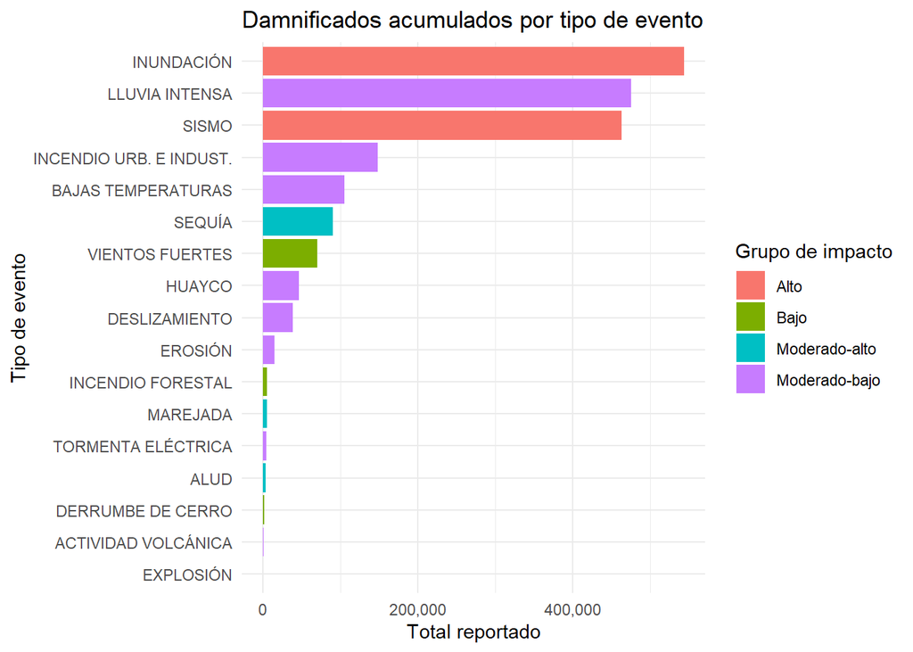

```r
ggplot(desc, aes(x = reorder(tipo_evento, total), y = total, fill = grupo_impacto)) +
  geom_col() + coord_flip() +
  scale_y_continuous(labels = label_number(big.mark = ",")) +
  labs(title = "Damnificados acumulados por tipo de evento", x = "Tipo de evento", y = "Total reportado", fill = "Grupo de impacto") + theme_minimal()
```

**Interpretación:** los totales reflejan la suma reportada en la hoja descriptiva. Las medias pueden estar influenciadas por valores extremos; revisar conjuntamente mediana, P75, P95 y porcentaje de ceros.

### A1.2 Normalidad y homogeneidad

**Código**

```r
normal |> kable()
```

| tipo_evento | n | p_valor | normal |
| --- | --- | --- | --- |
| ACTIVIDAD VOLCÁNICA | 68 | 0 | No |
| ALUD | 123 | 0 | No |
| BAJAS TEMPERATURAS | 200 | 0 | No |
| DERRUMBE DE CERRO | 200 | 0 | No |
| DESLIZAMIENTO | 200 | 0 | No |
| EROSIÓN | 200 | 0 | No |
| EXPLOSIÓN | 83 | 0 | No |
| HUAYCO | 200 | 0 | No |
| INCENDIO FORESTAL | 200 | 0 | No |
| INCENDIO URB. E INDUST. | 200 | 0 | No |
| INUNDACIÓN | 200 | 0 | No |
| LLUVIA INTENSA | 200 | 0 | No |
| MAREJADA | 122 | 0 | No |
| SEQUÍA | 200 | 0 | No |
| SISMO | 200 | 0 | No |
| TORMENTA ELÉCTRICA | 200 | 0 | No |
| VIENTOS FUERTES | 200 | 0 | No |

**Código**

```r
levene |> kable()
```

| Prueba | df1 | df2 | Estadistico | p_valor | Conclusion |
| --- | --- | --- | --- | --- | --- |
| Levene | 16 | 94852 | 61.653 | 1.06e-198 (p < 0.0001) | RECHAZADA — Varianzas heterogéneas → Kruskal-Wallis válido |

Las pruebas se presentan como **resultados ya calculados** en el libro fuente. No se ejecutan sobre medias agrupadas.

### A1.3 Hipótesis principal: Kruskal-Wallis

**Código**

```r
kw |> kable()
```

| Dataset | H | gl | p_valor | Decision | Robusto |
| --- | --- | --- | --- | --- | --- |
| Completo (n = 94,869) | 19413.49 | 16 | < 0.0001 | RECHAZAR H0 | — |
| Sin Pisco 2007 | 19407.05 | 16 | < 0.0001 | RECHAZAR H0 | SÍ |

**Código**

```r
eta |> kable()
```

| Prueba | H | k_grupos | n_total | eta2 | Interpretacion | Conclusion |
| --- | --- | --- | --- | --- | --- | --- |
| η² de Kruskal | 19413.49 | 17 | 94869 | 0.2045 | Grande (η² > 0.14) | El tipo de desastre explica el 20.45% de la variabilidad |

La hoja de Kruskal-Wallis reporta diferencias globales estadísticamente significativas entre tipos de evento. El contraste global no identifica por sí mismo qué pares difieren.

### A1.4 Comparaciones post hoc

**Código**

```r
dunn |> mutate(significativo = !is.na(p.adj) & p.adj < 0.05) |>
  count(significativo, name = "comparaciones") |> kable()
```

| significativo | comparaciones |
| --- | --- |
| FALSE | 48 |
| TRUE | 88 |

**Código**

```r
dunn |> filter(!is.na(p.adj), p.adj < 0.05) |>
  arrange(p.adj) |> select(group1, group2, statistic, p.adj, p.adj.signif) |>
  head(25) |> kable(digits = 5)
```

| group1 | group2 | statistic | p.adj | p.adj.signif |
| --- | --- | --- | --- | --- |
| BAJAS TEMPERATURAS | INCENDIO URB. E INDUST. | 121.83997 | 0 | **** |
| BAJAS TEMPERATURAS | INUNDACIÓN | 45.83363 | 0 | **** |
| BAJAS TEMPERATURAS | LLUVIA INTENSA | 50.53368 | 0 | **** |
| DESLIZAMIENTO | INCENDIO URB. E INDUST. | 46.99085 | 0 | **** |
| HUAYCO | INCENDIO URB. E INDUST. | 38.11427 | 0 | **** |
| INCENDIO FORESTAL | INCENDIO URB. E INDUST. | 67.32552 | 0 | **** |
| INCENDIO URB. E INDUST. | INUNDACIÓN | -40.95551 | 0 | **** |
| INCENDIO URB. E INDUST. | LLUVIA INTENSA | -85.72785 | 0 | **** |
| INCENDIO URB. E INDUST. | SEQUÍA | -60.39140 | 0 | **** |
| INCENDIO URB. E INDUST. | VIENTOS FUERTES | -75.25195 | 0 | **** |
| BAJAS TEMPERATURAS | VIENTOS FUERTES | 37.21777 | 0 | **** |
| DERRUMBE DE CERRO | INCENDIO URB. E INDUST. | 34.71513 | 0 | **** |
| BAJAS TEMPERATURAS | EROSIÓN | 32.52931 | 0 | **** |
| BAJAS TEMPERATURAS | SISMO | 31.57974 | 0 | **** |
| INCENDIO FORESTAL | INUNDACIÓN | 29.96906 | 0 | **** |
| INUNDACIÓN | SEQUÍA | -29.87605 | 0 | **** |
| EROSIÓN | SEQUÍA | -27.85206 | 0 | **** |
| SEQUÍA | SISMO | 26.87849 | 0 | **** |
| EROSIÓN | INCENDIO FORESTAL | -26.86106 | 0 | **** |
| BAJAS TEMPERATURAS | DESLIZAMIENTO | 26.09142 | 0 | **** |
| INCENDIO FORESTAL | SISMO | 25.83393 | 0 | **** |
| INCENDIO FORESTAL | LLUVIA INTENSA | 25.48902 | 0 | **** |
| LLUVIA INTENSA | SEQUÍA | -25.48294 | 0 | **** |
| SEQUÍA | VIENTOS FUERTES | 21.42778 | 0 | **** |
| BAJAS TEMPERATURAS | HUAYCO | 21.40242 | 0 | **** |

Se muestran las primeras 25 comparaciones significativas ordenadas por p ajustado. El archivo CSV contiene el conjunto completo.

### A1.5 Diferencias por región natural

**Código**

```r
region |> kable(digits = 3)
```

| region | n | H | p | sig | tipo_mayor | media_mayor |
| --- | --- | --- | --- | --- | --- | --- |
| COSTA | 15003 | 1478.39 | 0 | TRUE | SISMO | 1172.8 |
| SIERRA | 59029 | 11656.93 | 0 | TRUE | SISMO | 61.8 |
| SELVA ALTA | 8834 | 1170.47 | 0 | TRUE | SISMO | 63.7 |
| SELVA BAJA | 12003 | 1111.81 | 0 | TRUE | INUNDACIÓN | 233.1 |

**Código**

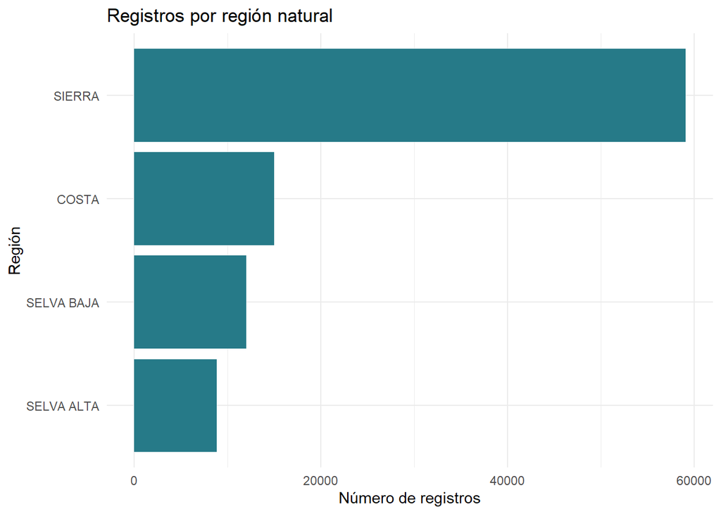

```r
ggplot(region, aes(x = reorder(region, n), y = n)) + geom_col(fill = "#267A88") + coord_flip() +
  labs(title = "Registros por región natural", x = "Región", y = "Número de registros") + theme_minimal()
```

## A2 · Preparación de características

La clasificación de impacto es una variable **ya derivada** en el Excel. No se estiman características a nivel de registro ni se hace partición de entrenamiento/prueba porque solo se dispone de tablas agregadas.

**Código**

```r
clasif |> arrange(desc(media)) |> kable(digits = 2)
```

| grupo_impacto | tipo_evento | n | mediana | media | P75 | P95 | RIC | pct_total |
| --- | --- | --- | --- | --- | --- | --- | --- | --- |
| Alto | SISMO | 1368 | 0 | 338.5 | 28.5 | 576.2 | 28.5 | 22.9 |
| Alto | INUNDACIÓN | 5786 | 0 | 94.0 | 7.0 | 175.0 | 7.0 | 26.9 |
| Moderado-alto | MAREJADA | 122 | 0 | 47.1 | 0.0 | 16.9 | 0.0 | 0.3 |
| Moderado-alto | SEQUÍA | 2181 | 0 | 41.4 | 0.0 | 0.0 | 0.0 | 4.5 |
| Moderado-alto | ALUD | 123 | 0 | 34.4 | 12.0 | 155.6 | 12.0 | 0.2 |
| Moderado-bajo | HUAYCO | 2276 | 0 | 20.4 | 1.0 | 80.0 | 1.0 | 2.3 |
| Moderado-bajo | LLUVIA INTENSA | 25262 | 0 | 18.8 | 4.0 | 53.0 | 4.0 | 23.5 |
| Moderado-bajo | ACTIVIDAD VOLCÁNICA | 68 | 0 | 15.3 | 0.0 | 25.4 | 0.0 | 0.1 |
| Moderado-bajo | EROSIÓN | 1297 | 1 | 11.9 | 6.0 | 54.0 | 6.0 | 0.8 |
| Moderado-bajo | DESLIZAMIENTO | 3662 | 0 | 10.5 | 2.8 | 48.0 | 2.8 | 1.9 |
| Moderado-bajo | TORMENTA ELÉCTRICA | 483 | 0 | 9.2 | 2.0 | 15.0 | 2.0 | 0.2 |
| Moderado-bajo | BAJAS TEMPERATURAS | 13601 | 0 | 7.7 | 0.0 | 0.0 | 0.0 | 5.2 |
| Moderado-bajo | INCENDIO URB. E INDUST. | 22531 | 5 | 6.6 | 7.0 | 17.0 | 7.0 | 7.3 |
| Bajo | VIENTOS FUERTES | 11810 | 0 | 6.0 | 2.0 | 27.0 | 2.0 | 3.5 |
| Bajo | EXPLOSIÓN | 83 | 0 | 3.7 | 0.0 | 18.6 | 0.0 | 0.0 |
| Bajo | DERRUMBE DE CERRO | 940 | 0 | 2.1 | 0.0 | 8.0 | 0.0 | 0.1 |
| Bajo | INCENDIO FORESTAL | 3276 | 0 | 1.8 | 0.0 | 5.0 | 0.0 | 0.3 |

## A3 · Selección de variables

Para un análisis posterior con microdatos se proponen como variables candidatas: tipo de evento, región natural y número de damnificados, siempre que existan como columnas originales. No se estima importancia predictiva con los resúmenes actuales.

## A4 · Reducción de dimensionalidad

No se ejecuta PCA: faltan las observaciones individuales y la matriz de variables originales. Aplicarlo a estos resúmenes respondería una pregunta distinta.

## A5 · Conclusiones y reproducibilidad

- Se documentan y visualizan las ocho hojas del Excel de INDECI.
- Los valores de las pruebas son resultados de origen, no nuevos cálculos.
- Se requiere la base individual para replicar inferencias, evaluar fuga de datos y continuar con modelos de ensamble.
- Evitar interpretar asociaciones entre grupos como causalidad.

**Uso de IA:** se utilizó asistencia para adaptar la estructura del laboratorio, generar scripts y documentar límites de reproducibilidad. Los resultados estadísticos proceden del Excel suministrado.